# EGU short course: 1. Spatiotemporal change detection

Meng Lu

April 18, 2017

## Method:

Integrate SAR (simutaneous autocorrelation regression) to the empirical fluctutaion process (efp) structural change test.

## What to do in the next 15 minutes:

- Seasonality analysis of a time series
- efp (empirical fluctuation process, from the R package “strucchange”) and BFAST (breaks for additive seasonality and trend, from the R package “BFAST”) methods for time series structural change detection.
- Spatial correlation of the area
- SAR integrated efp

## Start!

Load data, “fevi8” is a 3d array with longitude, latitude, and time as dimensions.

```r
load("fevi8.Rdata")
dim(fevi8)
```

```
## [1] 150 150 636
```

### Time series structural change analysis

#### 1. BFAST (breakpoints for additive seasonality and trend): detecting change in seasonality and trend interatively

Choose a location and form a time series from the data matrix

```r
lon = 60
lat = 40
originalts <- ts(fevi8[lon, lat, ], start = c(2000, 1), frequency = 46)
```

Assuming additive seasonality and trends, use stl (loess) to separate trend, seasonality and residuals.

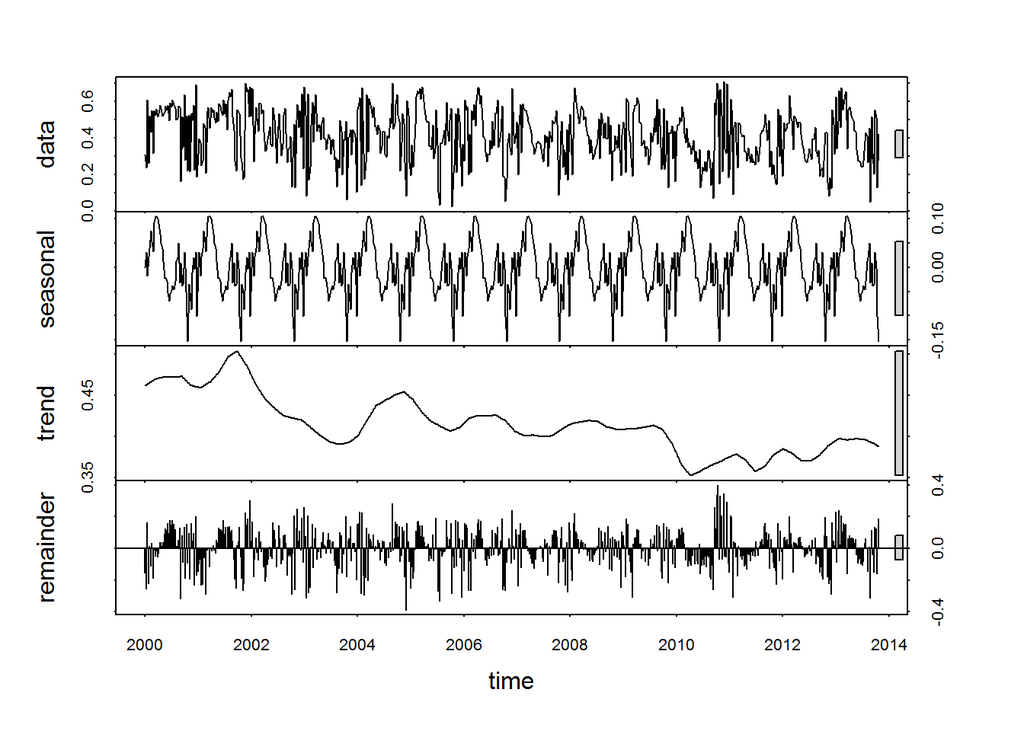

```r
seasonality <- stl(originalts, s.window = "per")$time.series[,
    "seasonal"]
plot(stl(originalts, s.window = "per"))
```

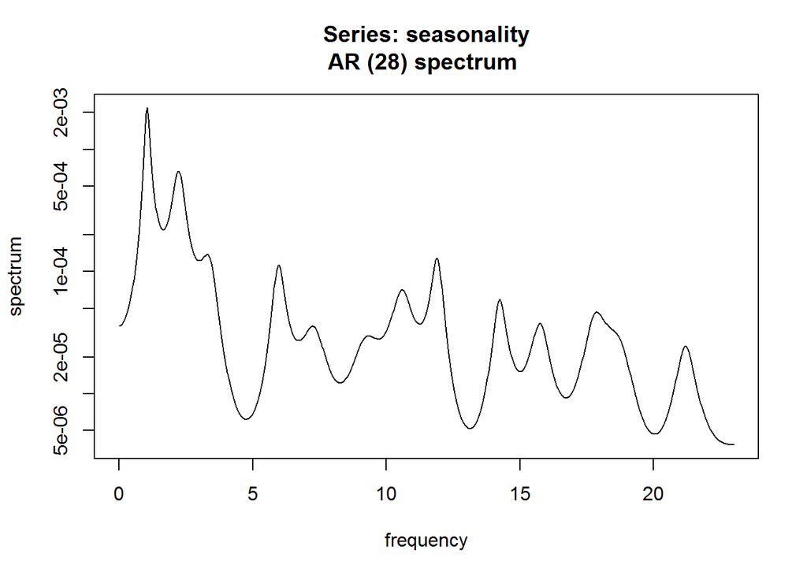

```r
spec.ar(seasonality)
```

Check seasonality and the ability of using a harmonic model to reduce seasonality.

Form harmonic terms.

```r
le = 636  # the length of time series
tl = 1:le
w = 1/46
# harmonic
co <- cos(2 * pi * tl * w)
si <- sin(2 * pi * tl * w)
co2 <- cos(2 * pi * tl * w * 2)
si2 <- sin(2 * pi * tl * w * 2)
co3 <- cos(2 * pi * tl * w * 3)
si3 <- sin(2 * pi * tl * w * 3)
```

Fit a first order harmonic model to the seasonality and model the seasonality in residuals.

```r
res_har1 <- residuals(lm(seasonality ~ co + si))
summary(lm(seasonality ~ co + si))
```

```
##
## Call:
## lm(formula = seasonality ~ co + si)
##
## Residuals:
##       Min        1Q    Median        3Q       Max
## -0.112342 -0.033067  0.003701  0.032908  0.094615
##
## Coefficients:
##              Estimate Std. Error t value Pr(>|t|)
## (Intercept) 0.0001968  0.0018132   0.109  0.91359
## co          0.0081433  0.0025719   3.166  0.00162 **
## si          0.0489322  0.0025566  19.140  < 2e-16 ***
## ---
## Signif. codes:  0 '***' 0.001 '**' 0.01 '*' 0.05 '.' 0.1 ' ' 1
##
## Residual standard error: 0.04572 on 633 degrees of freedom
## Multiple R-squared:  0.3735, Adjusted R-squared:  0.3715
## F-statistic: 188.7 on 2 and 633 DF,  p-value: < 2.2e-16
```

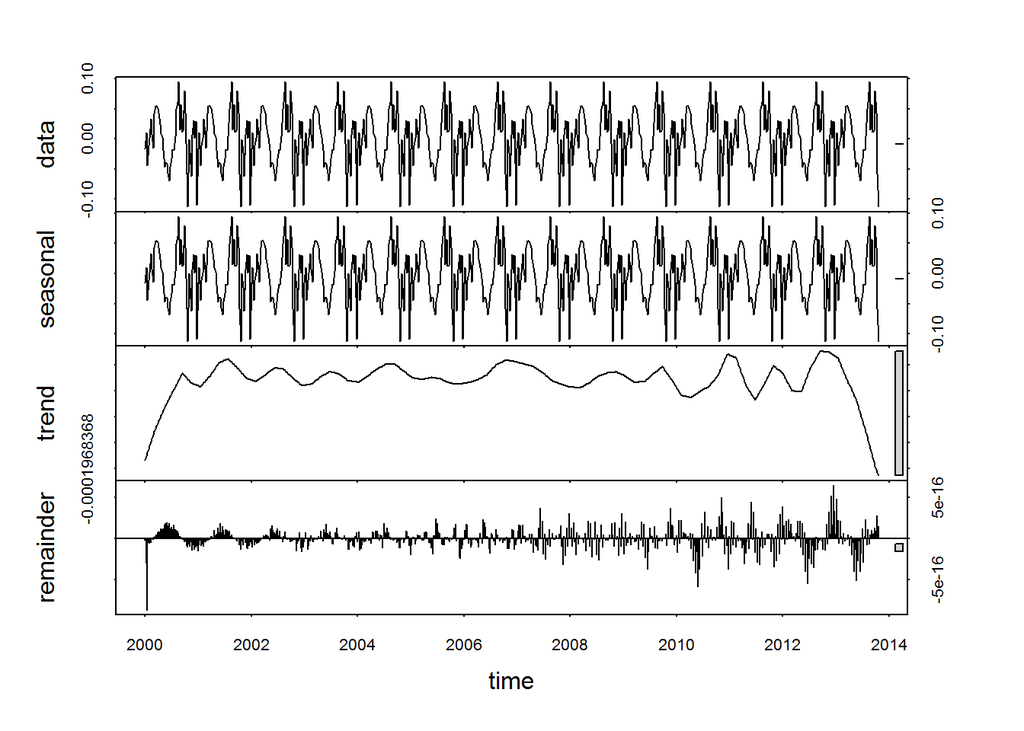

```r
res_har1 <- ts(res_har1, start = c(2000, 1), frequency = 46)
sea_har1 <- stl(res_har1, s.window = "per")$time.series[, "seasonal"]
plot(stl(res_har1, s.window = "per"))
```

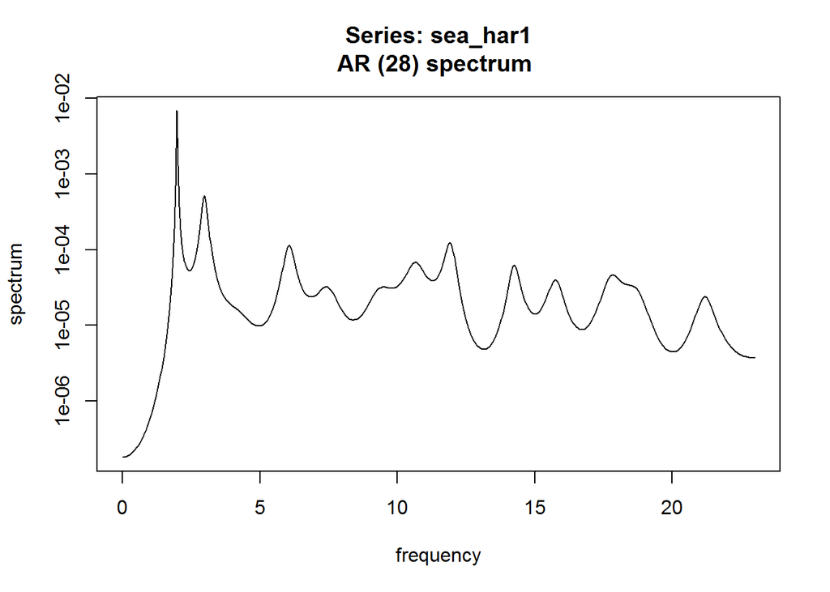

```r
spec.ar(sea_har1)
```

```r
res_har2 <- residuals(lm(seasonality ~ co + si + co2 + si2))
summary(lm(seasonality ~ co + si + co2 + si2))
```

```
##
## Call:
## lm(formula = seasonality ~ co + si + co2 + si2)
##
## Residuals:
##       Min        1Q    Median        3Q       Max
## -0.110493 -0.017217 -0.000125  0.022234  0.071803
##
## Coefficients:
##               Estimate Std. Error t value Pr(>|t|)
## (Intercept) -0.0002066  0.0014155  -0.146 0.884022
## co           0.0074311  0.0020079   3.701 0.000234 ***
## si           0.0492406  0.0019957  24.673  < 2e-16 ***
## co2         -0.0325992  0.0020000 -16.299  < 2e-16 ***
## si2          0.0240451  0.0020034  12.002  < 2e-16 ***
## ---
## Signif. codes:  0 '***' 0.001 '**' 0.01 '*' 0.05 '.' 0.1 ' ' 1
##
## Residual standard error: 0.03569 on 631 degrees of freedom
## Multiple R-squared:  0.6195, Adjusted R-squared:  0.6171
## F-statistic: 256.8 on 4 and 631 DF,  p-value: < 2.2e-16
```

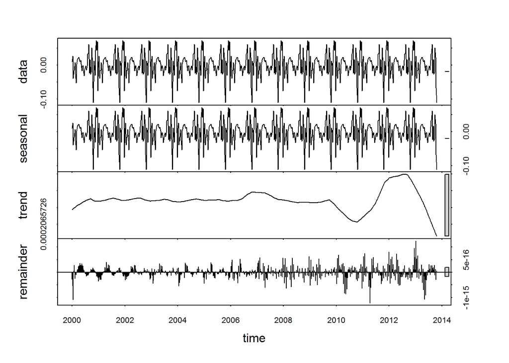

```r
res_har2 <- ts(res_har2, start = c(2000, 1), frequency = 46)
sea_har2 <- stl(res_har2, s.window = "per")$time.series[, "seasonal"]
plot(stl(res_har2, s.window = "per"))
```

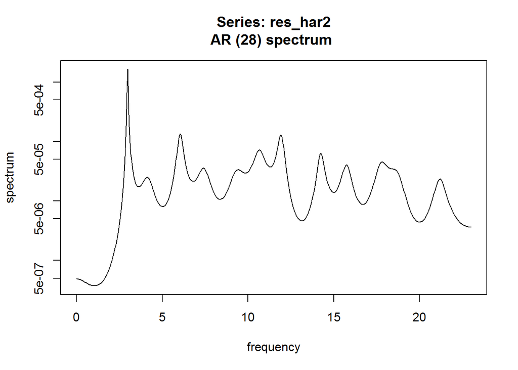

```r
spec.ar(res_har2)
```

```r
# res_har3 <- residuals(lm(seasonality ~ co + si +co2 + si2 +
# co3 + si3)) res_har3 <- ts(res_har3, start=c(2000, 1),
# frequency=46) sea_har3<- stl(res_har3, s.window =
# 'per')$time.series[,'seasonal'] plot(stl(res_har3, s.window
# = 'per')) spec.ar(sea_har3)
```

Use an empirical fluctuation test to test structural change in seasonality. The red lines indicate threshold of a change.

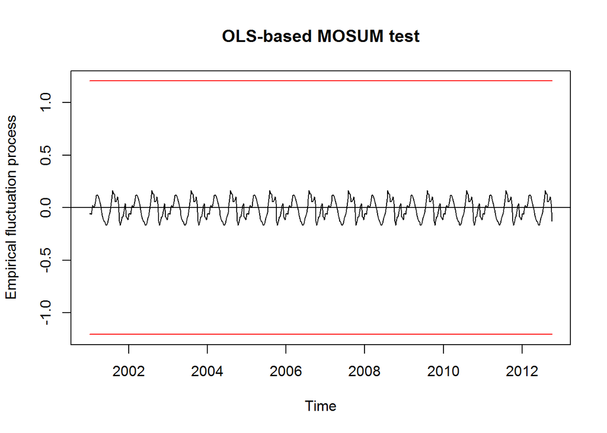

```r
efp_har1 <- efp(seasonality ~ co + si, type = "OLS-MOSUM")
plot(efp_har1)
```

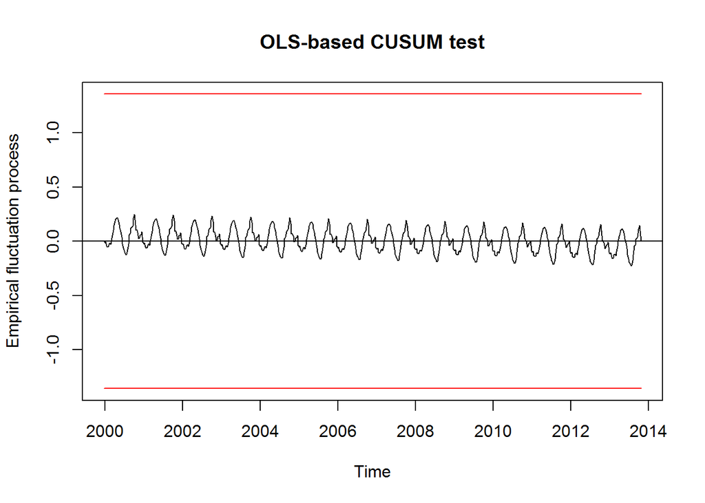

```r
efp_har1 <- efp(seasonality ~ co + si, type = "OLS-CUSUM")
plot(efp_har1)
```

```r
sctest(efp_har1)
```

```
##
##  OLS-based CUSUM test
##
## data:  efp_har1
## S0 = 0.24978, p-value = 1
```

Remove the seasonality.

```r
trend_rmstlsea <- originalts - seasonality
```

Check if any harmonic seasonality left after the seasonality is removed by stl:

```r
summary(lm(trend_rmstlsea ~ tl + co + si))
```

```
##
## Call:
## lm(formula = trend_rmstlsea ~ tl + co + si)
##
## Residuals:
##      Min       1Q   Median       3Q      Max
## -0.36592 -0.07655  0.00724  0.08918  0.37666
##
## Coefficients:
##               Estimate Std. Error t value Pr(>|t|)
## (Intercept)  4.635e-01  1.022e-02  45.349  < 2e-16 ***
## tl          -1.524e-04  2.781e-05  -5.480 6.14e-08 ***
## co           3.289e-04  7.237e-03   0.045    0.964
## si          -1.526e-03  7.198e-03  -0.212    0.832
## ---
## Signif. codes:  0 '***' 0.001 '**' 0.01 '*' 0.05 '.' 0.1 ' ' 1
##
## Residual standard error: 0.1286 on 632 degrees of freedom
## Multiple R-squared:  0.04541,    Adjusted R-squared:  0.04087
## F-statistic: 10.02 on 3 and 632 DF,  p-value: 1.853e-06
```

Use the empirical fluctuation test to test structural change in trend. The red lines indicate threshold of a change.

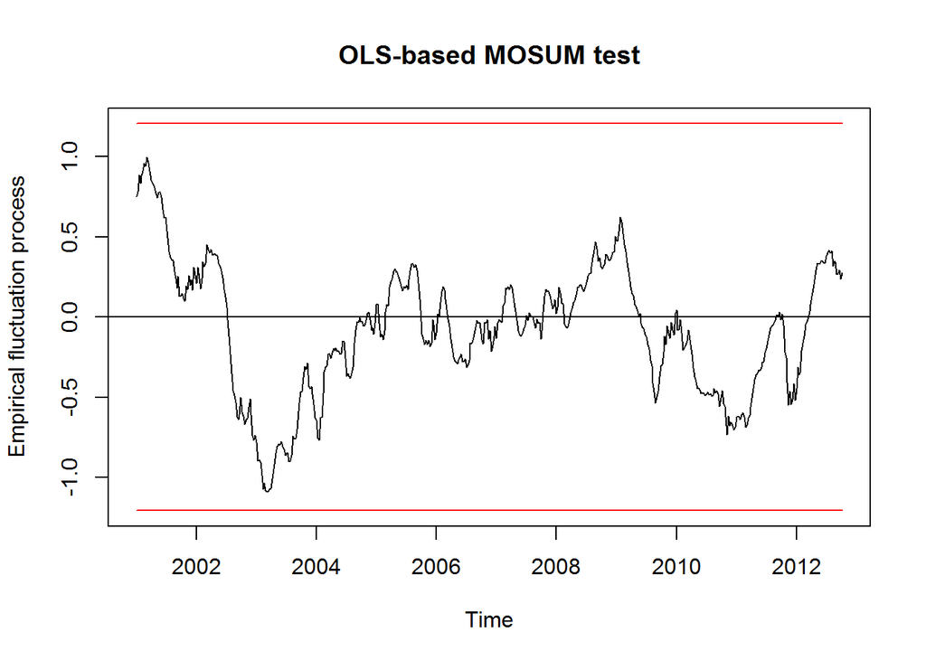

```r
efp_trend <- efp(trend_rmstlsea ~ tl, type = "OLS-MOSUM")
plot(efp_trend)
```

```r
sctest(efp_trend)
```

```
##
##  OLS-based MOSUM test
##
## data:  efp_trend
## M0 = 1.0889, p-value = 0.1259
```

#### 2. Regression on trend and harmonic terms at once: the BFAST Monitor method:

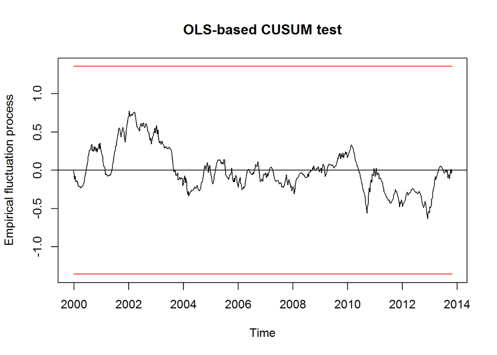

```r
p.Vt1 <- efp(originalts ~ tl + co + co2 + co3 + si + si2 + si3,
    h = 0.15, type = "OLS-CUSUM")
plot(p.Vt1)
```

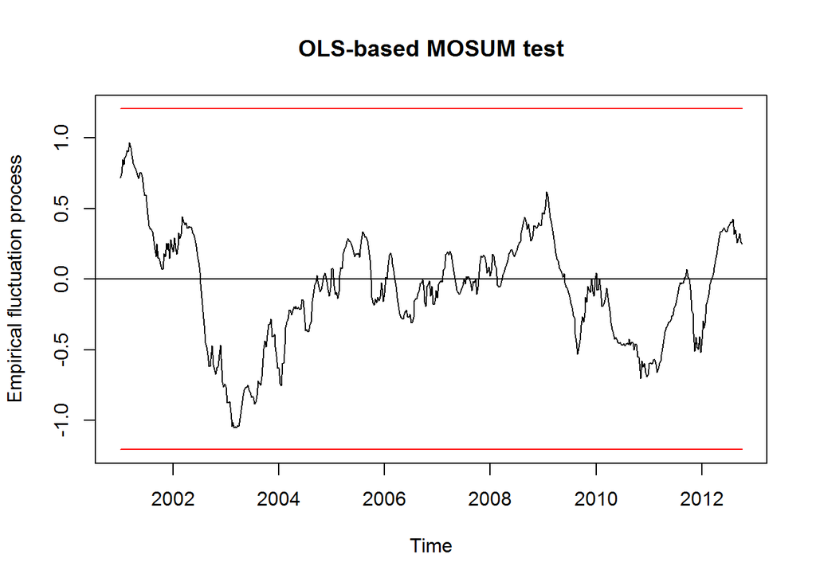

```r
p.Vt1 <- efp(originalts ~ tl + co + co2 + co3 + si + si2 + si3,
    h = 0.15, type = "OLS-MOSUM")
plot(p.Vt1)
```

### Spatial correlation

Here we checked a parameter (e.g. cosine coefficient) of seasonality. We could also check the spatial correlation in seasonality of model (e.g. BFAST) residuals, trend coefficients, as well as other seasonality coefficients.

```r
coef_sea <- function(ts1, whichcoef) {
    originalts <- ts(ts1, start = c(2000, 1), frequency = 46)
    seasonality <- stl(originalts, s.window = "per")$time.series[,
        "seasonal"]
    trend = originalts - seasonality
    coefficients(lm(seasonality ~ co + si))[whichcoef]
}
seacoefco <- apply(fevi8, c(1, 2), coef_sea, 2)  # coefficients of the consine term
seacoefsi <- apply(fevi8, c(1, 2), coef_sea, 3)  # coefficients of the sine term
save(seacoefsi, file = "seacoefsi.Rdata")
save(seacoefco, file = "seacoefco.Rdata")
```

The seasonality coefficient takes around 1 min to run. In case of saving some time, we can load the seasonality coefficeints.

```r
load("seacoefsi.Rdata")
load("seacoefco.Rdata")
```

We could see a spatial pattern in the seasonality coefficient: the sine term

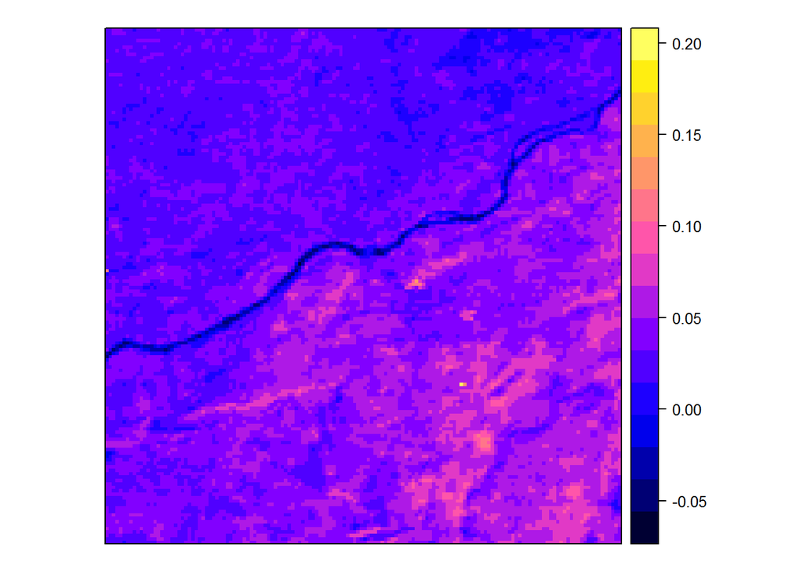

```r
coor <- expand.grid(x = 1:dim(fevi8)[1], y = 1:dim(fevi8)[2])
sdfsi <- data.frame(seacoef = as.vector(seacoefsi), coor)
coordinates(sdfsi) <- ~x + y
sdf1 <- sdfsi
gridded(sdf1) <- TRUE
spplot(sdf1)
```

We could see a spatial pattern in the seasonality coefficient: the cosine term

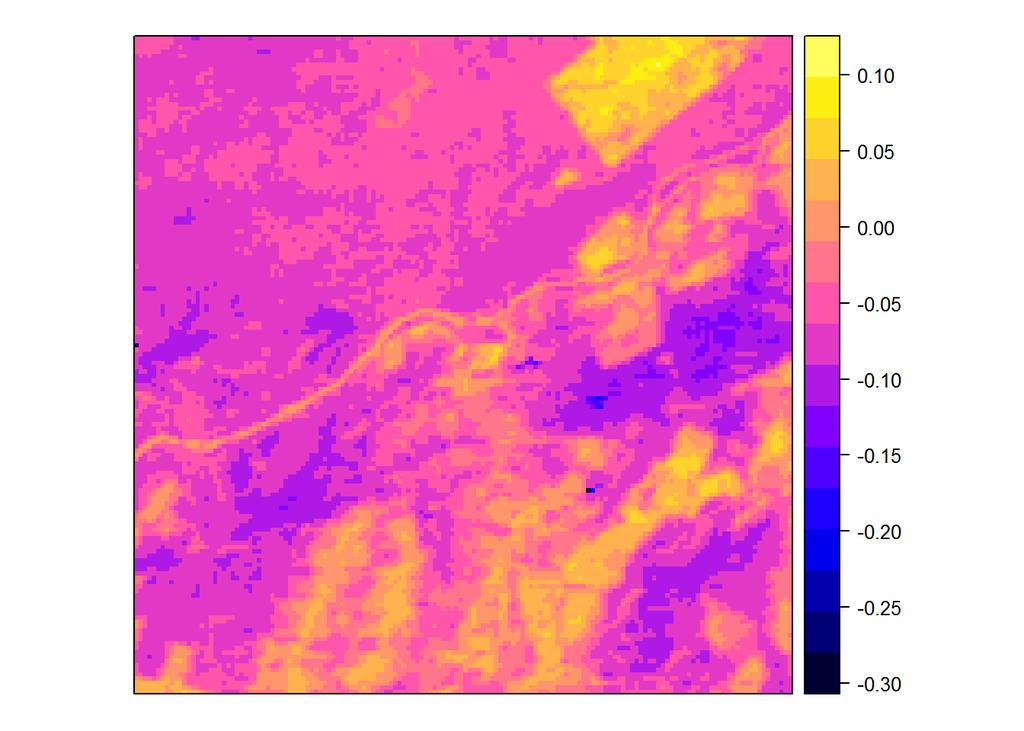

```r
sdfco <- data.frame(seacoef = as.vector(seacoefco), coor)
coordinates(sdfco) <- ~x + y
sdf1 <- sdfco
gridded(sdf1) <- TRUE
spplot(sdf1)
```

We could also have a look at the variogram and fit a variogram model. Here I regressed on locations to get rid of spatial trend. It is clear that semivariance increase with distance, which indicates spatial correlation. The sine term

```r
v <- variogram(seacoef ~ x + y, sdfsi)
model3d <- fit.variogram(v, vgm(c("Exp", "Ste", "Sph", "Mat",
    "Gau")))
model3d
```

```
##   model        psill    range kappa
## 1   Nug 7.378884e-05  0.00000   0.0
## 2   Ste 1.301794e-04 15.48218   0.5
```

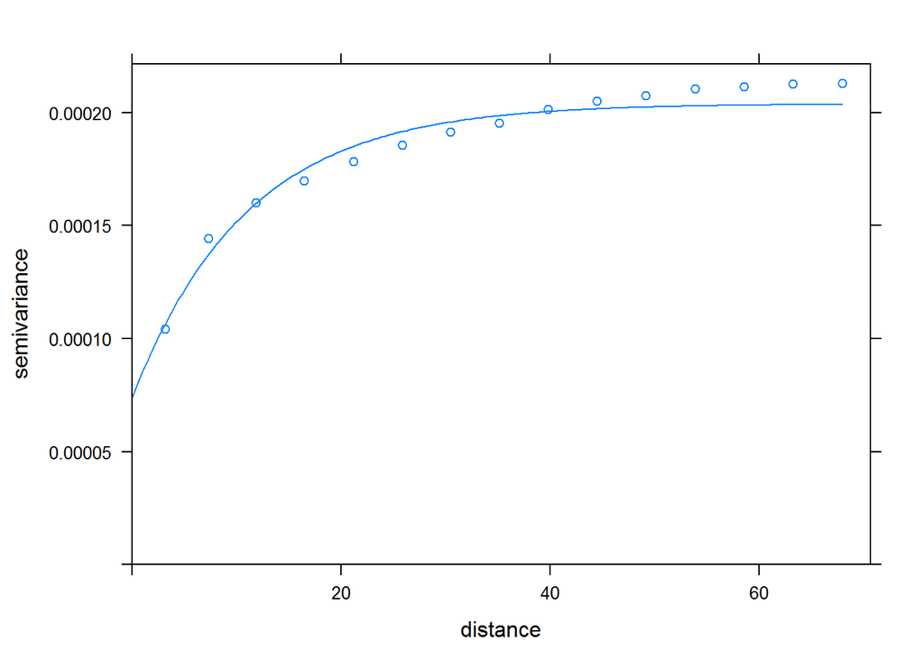

```r
plot(v, model3d)
```

The cosine term:

```r
v <- variogram(seacoef ~ x + y, sdfco)
model3d <- fit.variogram(v, vgm(c("Exp", "Ste", "Sph", "Mat",
    "Gau")))
model3d
```

```
##   model        psill    range
## 1   Nug 9.969915e-05  0.00000
## 2   Sph 1.239729e-03 27.42691
```

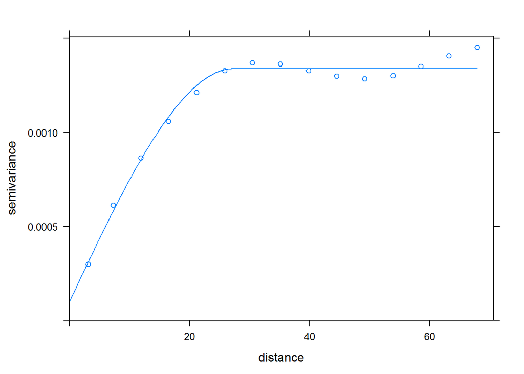

```r
plot(v, model3d)
```

#### SAR integrated efp model:

Create spatiotemporal cubes and weight matrix.

```r
eday <- as.Date("2000-01-30")  # date
e8day <- seq(eday, length.out = 636, by = "8 days")
xyd <- expand.grid(x1 = 1:3, y1 = 1:3)
coordinates(xyd) <- ~x1 + y1
lecube <- 3 * 3 * 636
aa3 <- as.data.frame(c(1:lecube))
stfdf3b3 <- STFDF(xyd, e8day, aa3)  ## for creating neighbors only, aa3 could be any data
cn <- cell2nb(3, 3, type = "queen", torus = FALSE)
neigh1 <- nbMult(cn, stfdf3b3, addT = FALSE, addST = FALSE)  # only spatial neighbours are added for each time step
listcn636 <- nb2listw(neigh1)
```

Regressors (trend and seasonality) in a matrix

```r
X = matrix(0, 636 * 9, 9 * 8)

for (i in 1:9) {
    X[seq(i, by = 9, length.out = 636), 1 + (i - 1) * 8] = 1
    X[seq(i, by = 9, length.out = 636), 2 + (i - 1) * 8] = tl
    X[seq(i, by = 9, length.out = 636), 3 + (i - 1) * 8] = co
    X[seq(i, by = 9, length.out = 636), 4 + (i - 1) * 8] = co2
    X[seq(i, by = 9, length.out = 636), 5 + (i - 1) * 8] = co3
    X[seq(i, by = 9, length.out = 636), 6 + (i - 1) * 8] = si
    X[seq(i, by = 9, length.out = 636), 7 + (i - 1) * 8] = si2
    X[seq(i, by = 9, length.out = 636), 8 + (i - 1) * 8] = si3
    colnames(X) = paste0("v", 1:(9 * 8))
    X
}
```

Load the modified version of strucchange, the only difference is the change in the efp function, for OLS-MOSUM and OLS-CUSUM tests. In the modified verson, structural change is analysed directly from the residuals of spatialtemporal model. The function efp() takes a “spatial1” variable (i.e. the modified version of efp: efp <- function(…., spatial1 = list())) and skip the linear regression formula. The “spatial1” contains a list of residuals from SAR integrated time series regression mode.

```r
library(devtools)
install_github("mengluchu/strucchange", build_vignettes = FALSE)
```

```r
f2 <- fevi8[(lon - 1):(lon + 1), (lat - 1):(lat + 1), ]
fevi3b312t1 <- ts(f2[2, 2, ], start = c(2000, 1), frequency = 46)  # reconstruct the time series
aa2 <- as.vector(f2)
system.time(try2 <- spautolm(aa2 ~ ., data.frame(aa2, X), family = "SAR",
    method = "Matrix", listw = listcn636))
```

```
##    user  system elapsed
##   24.55    0.79   25.56
```

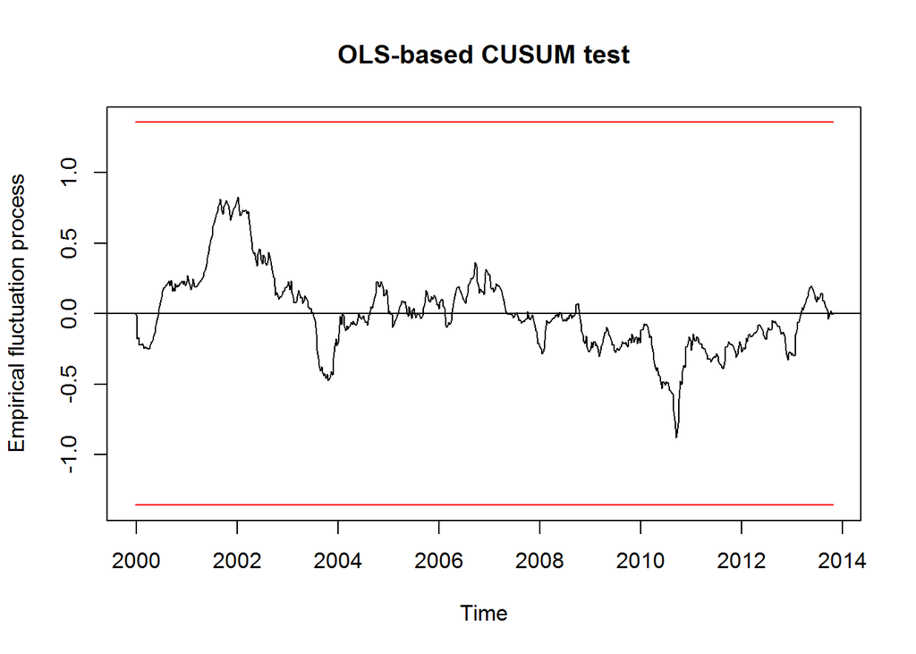

```r
rn <- lapply(1:9, function(i) {
    residuals(try2)[seq(i, 636 * 9 - (9 - i), 9)]
})
p.Vt1 <- efp(fevi3b312t1 ~ 1, h = 0.15, type = "OLS-CUSUM", spatial1 = as.numeric(rn[[5]]))
plot(p.Vt1)
```

```r
sctest(p.Vt1)$p.value
```

```
##        S0
## 0.4229956
```

OLS-MOSUM method:

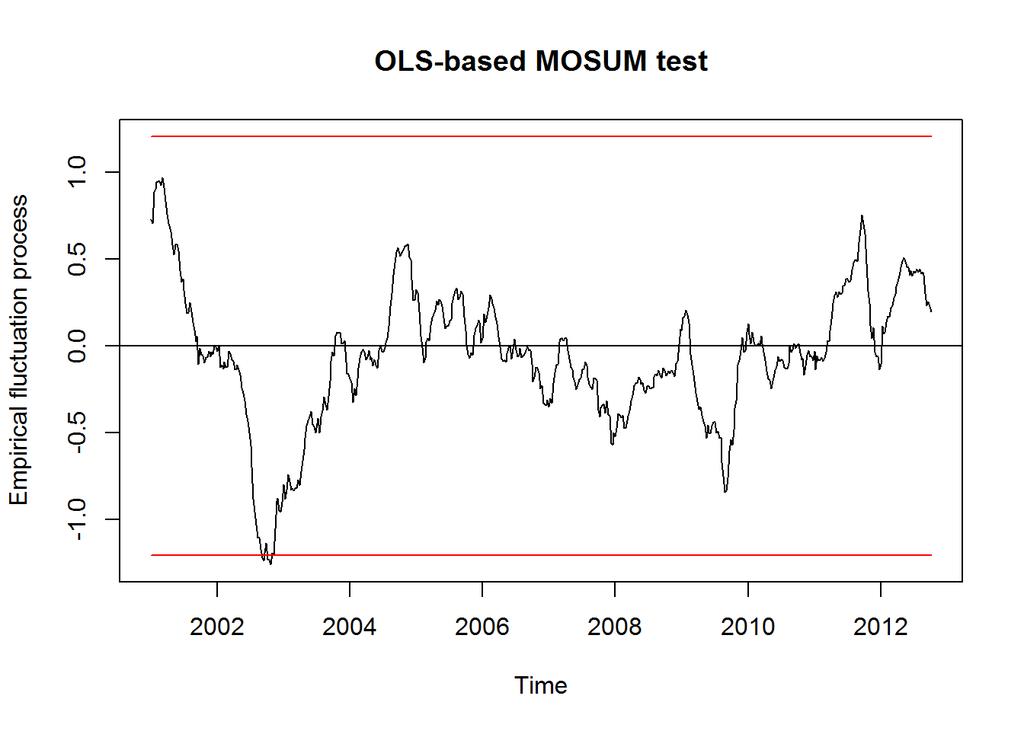

```r
p.Vt1 <- efp(fevi3b312t1 ~ 1, h = 0.15, type = "OLS-MOSUM", spatial1 = as.numeric(rn[[5]]))
plot(p.Vt1)
```

Comparing with the pure time series anaylsis: OLS-CUSUM

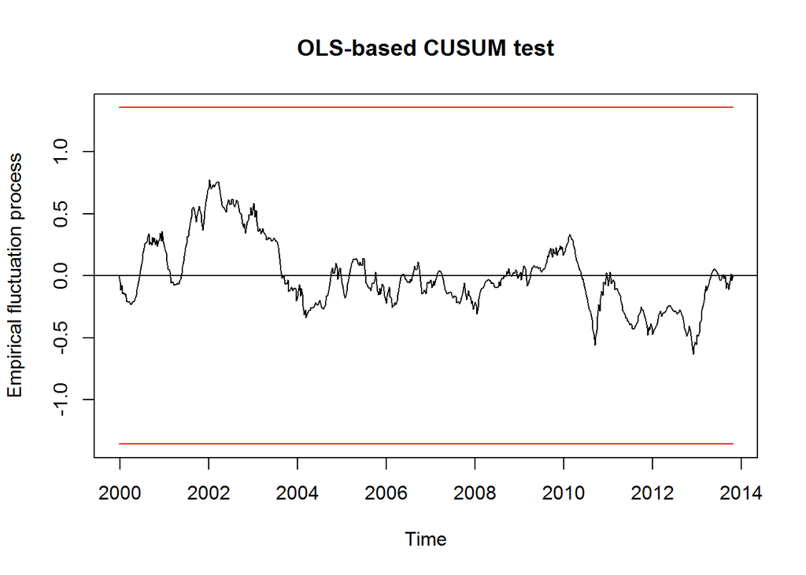

```r
p.Vt1 <- efp(fevi3b312t1 ~ tl + co + co2 + co3 + si + si2 + si3,
    h = 0.15, type = "OLS-CUSUM")
plot(p.Vt1)
```

OLS-MOSUM

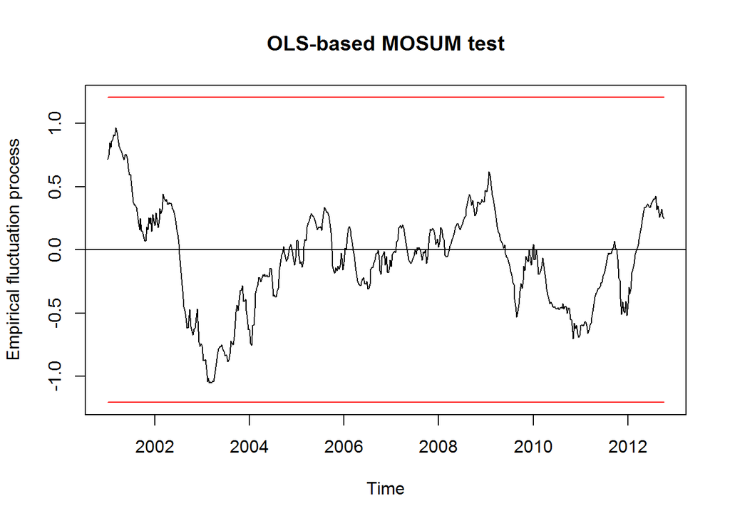

```r
p.Vt1 <- efp(fevi3b312t1 ~ tl + co + co2 + co3 + si + si2 + si3,
    h = 0.15, type = "OLS-MOSUM")
plot(p.Vt1)
```

Detect change using structural change test and store the p-value into an array. Here is an example conduct the analysis for 4 $3*3*636$ spatiotemporal cubes.

```r
tssar1 <- array(NA, c(2, 2))

for (i in 30:31) {
    for (j in 30:31) {
        f2 <- fevi8[i:(i + 2), j:(j + 2), ]
        fevi3b312t1 <- ts(f2[2, 2, ], start = c(2000, 1), frequency = 46)  # reconstruct the time series
        aa2 <- as.vector(f2)
        try2 <- spautolm(aa2 ~ ., data.frame(aa2, X), family = "SAR",
            method = "Matrix", listw = listcn636)
        rn <- lapply(1:9, function(i) {
            residuals(try2)[seq(i, 636 * 9 - (9 - i), 9)]
        })
        p.Vt1 <- sctest(efp(fevi3b312t1 ~ 1, h = 0.15, type = "OLS-CUSUM",
            spatial1 = as.numeric(rn[[5]])))
        tssar1[i, j] < -p.Vt1$p.value
    }
}
```

Pure time series analysis:

```r
ts1 <- array(NA, c(2, 2))
system.time(for (i in 1:2) {
    for (j in 1:2) {
        f2 <- fevi8[i:(i + 2), j:(j + 2), ]
        fevi3b312t1 <- ts(f2[2, 2, ], start = c(2000, 1), frequency = 46)  # reconstruct the time series
        p.Vt1 <- sctest(efp(fevi3b312t1 ~ tl + co + co2 + co3 +
            si + si2 + si3, h = 0.15, type = "OLS-CUSUM"))
        ts1[i, j] <- p.Vt1$p.value
    }
})
```

P-values for each pixels.

```r
tssar1
ts1
```

[output not shown]

## Scale the SAR-efp with SciDB and reproduce the results of a study case in “Spatio-Temporal Change Detection from Multidimensional Arrays: detecting deforestation from MODIS time series”, ISPRS journal, Mar, 2016. The study area is in Juara, Brazil:

https://github.com/mengluchu/scalable-spatial-temporal-BFAST